# Årets tema - sykefravær

Derek og Mikko

13/01/2025

## Aktuell debatt: Sykefravær og sykelønn

[figure not shown]

[figure not shown]

[figure not shown]

## Hvorfor er det viktig å analysere faktorene som påvirker sykefraværet i Norge?

#### Økonomiske konsekvenser

- **Kostnader for samfunnet**: Høyt sykefravær belaster velferdsordninger som sykepenger og fører til tapte skatteinntekter.
- **Kostnader for arbeidsgivere**: Økt fravær gir produktivitetstap og høyere utgifter til vikarer eller overtid.
- **Bærekraft i velferdssystemet**: Redusert sykefravær kan sikre langsiktig finansiering av offentlige tjenester.

#### Arbeidstakernes helse og velferd

- Forstå hvilke faktorer som driver sykefravær kan bidra til:
  - **Bedre arbeidsmiljø**: Identifisere og redusere arbeidsrelaterte helseproblemer.
  - **Individuell oppfølging**: Målrettede tiltak for arbeidstakere med høy risiko for langtidsfravær.
  - **Forebygging**: Styrke helsefremmende tiltak både på arbeidsplassen og i samfunnet.

#### Samfunnsmessige gevinster

- **Økt produktivitet**: Lavere fravær kan gi bedre ressursutnyttelse i økonomien.
- **Inkludering i arbeidslivet**: Bedre forståelse kan bidra til å redusere frafall fra arbeidsmarkedet.
- **Bedre livskvalitet**: Redusert sykefravær kan styrke både helse og økonomisk trygghet.

#### Kunnskap for fremtiden

- **Forutse trender**: Hvordan endringer i arbeidsmarkedet, teknologi og helse påvirker sykefravær.
- **Internasjonale sammenligninger**: Lær av erfaringer i andre land for å forbedre norske ordninger.

## Sykelønn/sykepenger

- Arbeidsgiveren utbetaler sykepenger for de første 16 kalenderdagene
- 100 % dekning: man kan få sykepenger som tilsvarer full lønn fra arbeidsgiveren din, men man har ikke rett til et sykepengegrunnlag som overstiger 6G
- 52 uker makstid
- Egenmelding betyr at du melder fra til arbeidsgiveren din om at du er syk, uten at du leverer sykmelding
- Ved gradert (delvis) sykmelding har du rett til sykepenger for den delen du er syk
  - sykepengene kan graderes fra 100 prosent og ned til 20 prosent

## Sykefravær, egenmeldt og legemeldt

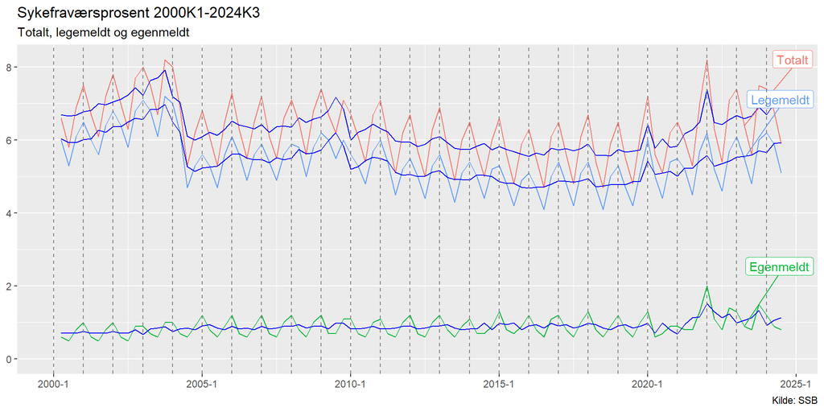

## Sykefravær pr. kjønn

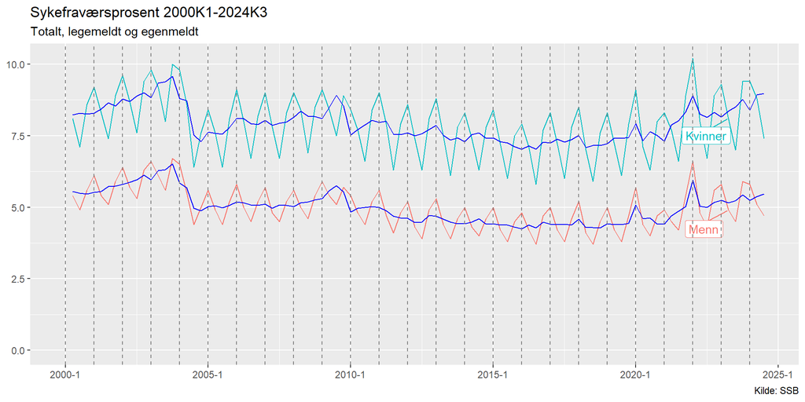

## Hva blir folk syk av

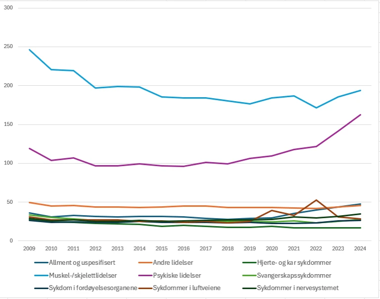

Andel tapte dagsverk per 10 000 avtalte arbeidsdager. Etter diagnosegrupper. 2. kvartal, 2009-2024. Kilde: NAV

## Sykefravær med diagnoser under gruppen psykiske lidelser

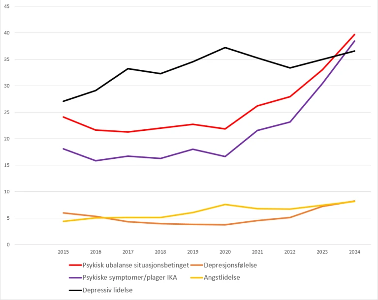

Sykefravær med enkelte diagnoser under gruppen psykiske lidelser. Andel tapte dagsverk per 10 000 avtalte dagsverk. 2. kvartal i årene 2015 – 2024. Kilde: NAV

## Norge har høyt sykefravær internasjonalt

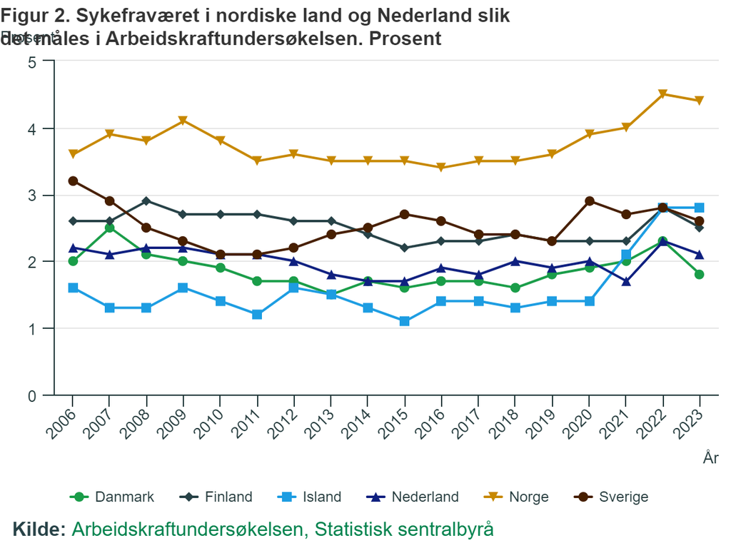

## Oppsummering av forskningsresultatene

se mer [her](https://www.regjeringen.no/globalassets/upload/asd/dokumenter/2014/rapporter/rapport_2014_05_internasjonal_sammenligning_av_sykefravaer_del_2.pdf)

**Kjønnsforskjeller**

- Kvinners sykefravær er høyere enn menns i de fleste land.
  - En del av forskjellen kan forklares med graviditetsrelatert fravær.
  - Selv etter å ha kontrollert for en rekke observerbare faktorer, gjenstår det en betydelig uforklart forskjell i alle studier.

**Helse**

- Forskjeller i selvrapportert helse kan forklare noe av kjønnsforskjellene i sykefravær.
- Tolkningen av disse forskjellene er imidlertid usikker

**Arbeidsmiljø og arbeidssituasjon**

- Det er omfattende forskning på betydningen av arbeidsmiljø og arbeidssituasjon.
- Arbeidsmiljøet har stor innvirkning, men forskningen gir sprikende resultater om hvilke aspekter som er mest avgjørende.
- **Arbeidstid**  
  Forskningen om sammenhengen mellom arbeidstid og sykefravær gir ikke grunnlag for entydige konklusjoner.

**Familiesituasjon**

- Sammenhengen mellom omsorgsbyrde og sykefravær er blitt grundig undersøkt.
- Studier av korrelasjonen mellom fravær og antall barn gir blandede resultater.
- De fleste studier finner ingen vesentlig forskjell eller viser at kvinner med barn har lavere fravær enn kvinner uten barn.
- Enkelte studier antyder at dette kan skyldes en seleksjonseffekt, og at det å få barn kan føre til en moderat økning i fraværet.

**Stillingsvern og kontraktsform**

- Studier av samvariasjonen mellom styrken i stillingsvernet og nivået på sykefraværet indikerer en positiv sammenheng.
- Endringer i stillingsvernet ser ut til å bidra til høyere sykefravær når vern styrkes.
- Flere studier viser at fast ansatte har høyere sykefravær enn midlertidig ansatte.
- Det finnes også forskning som ikke finner noen sammenheng mellom kontraktsform og sykefravær.

**Holdninger og normer**

- Empirisk forskning tolker ofte uforklarte forskjeller som resultat av ulike holdninger.
- Eksempelvis viser studier “uforklarlige” variasjoner i sykemeldingspraksis blant leger, som tolkes som ulike normer eller terskler for sykemelding.
- Forskning viser også at sykefraværet er lavere i små virksomheter sammenlignet med store.
- Dette kan tolkes som et resultat av sterkere pliktfølelse hos ansatte i små virksomheter.
  - Alternativt kan det skyldes at fravær blir mer synlig i små organisasjoner.

# Teori

## Kjønnsforskjeller

**Teoretiske rammeverk og prediksjoner:**

- **Neoklassisk arbeidstilbudsmodell:**
  - Kvinner kan ha høyere sykefravær enn menn grunnet ulike preferanser for fritid og arbeid.
  - kan i større grad verdsette fritid på grunn av omsorgsoppgaver eller andre forpliktelser utenfor arbeidslivet
- **Teorier om sosiale normer:**
  - Sosiale normer kan skape forventninger om høyere arbeidsbelastning for kvinner, noe som kan bidra til høyere sykefravær.

**Resultater og referanser:**

- **Resultat:** Studier viser uforklarte kjønnsforskjeller i sykefravær selv etter kontroll for observerbare faktorer.
  - [**Lima, I. (2024). Har kvinner høyere sykefravær fordi de oftere er syke?. *Arbeid og Velferd*, *1*, 24**](https://bibliotek.nav.no/record/4659/files/03-0124_Arbeid_og_velferd-0124_Har%20kvinner%20h%C3%B8yere%20sykefrav%C3%A6r%20fordi%20de%20oftere%20er%20syke.pdf)**:** kvinners høyere sykefravær i stor grad skyldes at de oftere har diagnoser som de har større sykdomsrisiko for enn menn, som depresjon, angst, migrene og autoimmune lidelser
  - [**Timp, S., van Foreest, N., & Roelen, C. (2024). Gender differences in long term sickness absence. *BMC Public Health*, *24*(1), 178**](https://link.springer.com/article/10.1186/s12889-024-17679-8)**:** kvinner har lengre sykefravær enn menn, spesielt når det gjelder psykiske lidelser og muskel- og skjelettlidelser.

## Helse

**Teoretiske rammeverk og prediksjoner:**

- **Neoklassisk arbeidstilbudsmodell:**
  - Dårlig helse øker preferansen for fritid og reduserer arbeidstilbudet
- **Demand-Control-hypotesen:**
  - Høye arbeidskrav og lav kontroll forverrer helsen og øker sannsynligheten for sykefravær.

**Resultater og referanser:**

- **Resultat:** Selvrapporterte helseindikatorer forklarer noen forskjeller i sykefravær, men subjektive tolkninger gjør analysene krevende.
  - [**Halford, C., Wallman, T., Welin, L., Rosengren, A., Bardel, A., Johansson, S., … & Svärdsudd, K. (2012). Effects of self-rated health on sick leave, disability pension, hospital admissions and mortality. A population-based longitudinal study of nearly 15,000 observations among Swedish women and men. *BMC Public Health*, *12*, 1-11**](https://link.springer.com/article/10.1186/1471-2458-12-1103)**:** dårlig selvvurdert helse er en sterk indikator for økt sykefravær

## Arbeidsmiljø og arbeidssituasjon

**Teoretiske rammeverk og prediksjoner:**

- **Effektiv lønnsteori:**
  - Bedre arbeidsforhold og høyere lønn reduserer fravær ved å øke trivsel.
- **Demand-Control-hypotesen:**
  - Dårlig arbeidsmiljø, særlig kombinasjonen av høye krav og lav kontroll, øker sykefraværet.

**Resultater og referanser:**

- **Resultat:** Dårlige arbeidsforhold øker sannsynligheten for sykefravær, men det er sprikende funn om hvilke faktorer som er viktigst.
  - [**Knardahl, S., Sterud, T., Nielsen, M. B., & Nordby, K. C. (2016). Arbeidsplassen og sykefravær-Arbeidsforhold av betydning for sykefravær. *Tidsskrift for velferdsforskning*, *19*(2), 179-199.**](https://stami.no/publikasjon/arbeidsplassen-og-sykefravaer-arbeidsforhold-av-betydning-for-sykefravaer)**:** Høy grad av selvbestemmelse, kontroll over arbeidstid og et positivt sosialt klima reduserer risikoen for sykefravær, mens høye krav kombinert med lav kontroll, mobbing og fysisk belastende arbeid øker risikoen

## Arbeidstid

**Teoretiske rammeverk og prediksjoner:**

- **Neoklassisk arbeidstilbudsmodell:**
  - Hvis arbeidstd ikke er optimal for individet kan dette føre til økt sannsynlighet for sykefravær.

**Resultater og referanser:**

- **Resultat:** Lange arbeidstider kan føre til økt fravær, men funnene er varierende.
  - **Bernstrøm, V. H., & Houkes, I. (2018). A systematic literature review of the relationship between work hours and sickness absence. *Work & Stress*, *32*(1), 84-104:** sammenhengen mellom arbeidstid og sykefravær er kompleks, med varierende resultater avhengig av arbeidstidsmønstre, individuelle forskjeller og jobbkarakteristika
- **NAV-rapporter:** Lange arbeidstider er assosiert med økt sykefravær i visse yrker. (nav.no)

## Familiesituasjon og omsorgsbyrde

**Teoretiske rammeverk og prediksjoner:**

- **Seleksjonshypotesen:**
  - Kvinner med omsorgsforpliktelser kan være selektert mot høyere arbeidskapasitet, noe som forklarer lavere fravær i enkelte grupper.
- **Neoklassisk arbeidstilbudsmodell:**
  - Omsorgsbyrde øker verdien av fritid, noe som kan øke sannsynligheten for fravær.
- **Dobbeltarbeidshypotesen:**
  - kvinners høyere sykefravær kan skyldes en kombinasjon av lønnsarbeid og ulønnet omsorgsarbeid i hjemmet, noe som kan føre til økt belastning og dermed høyere sykefravær

**Resultater og referanser:**

- **Resultat:**
  - [**Mykletun,** **A., Evensen, M., Hagen, K., & Vaage, K. (2012). Hvorfor øker kjønnsforskjellen i sykefravær mellom kvinner og menn?. *Tidsskrift for Norsk psykologforening*, *49*(6)**](https://www.psykologtidsskriftet.no/artikkel/2012as06ae-Hvorfor-%C3%B8ker-kj%C3%B8nnsforskjellen-i-sykefrav%C3%A6r-mellom-kvinner-og-menn-)**:** diskuterer hvordan kombinasjonen av lønnsarbeid og omsorgsforpliktelser kan bidra til kvinners høyere sykefravær.
  - [**Angelov, N., Johansson, P., & Lindahl, E. (2020): *“Sick of family responsibilities?”* Empirical Economics, 58(2), 777–814**](https://link.springer.com/article/10.1007/s00181-018-1552-2): økt omsorgsansvar etter foreldreskap kan føre til høyere sykefravær blant mødre, uten en tilsvarende forverring i objektiv helse.

## Stillingsvern og kontraktsform

**Teoretiske rammeverk og prediksjoner:**

- **Shirking-modellen:**
  - Sterkere stillingsvern øker fravær ved å redusere risikoen for konsekvenser.
  - Lav risiko for oppsigelse øker fraværsnivået.
- **Effektiv lønnsteori:**
  - Midlertidige ansatte kan ha lavere fravær på grunn av usikkerhet.

**Resultater og referanser:**

- **Resultat:** Fast ansatte har høyere sykefravær enn midlertidige ansatte.
  - [**Josephson, Malin, H. Persson-Schill, and S. Bjurström. “Sickness absence and temporary employment in Sweden” *The European Journal of Public Health* 27.suppl_3 (2017): ckx189-136:**](https://academic.oup.com/eurpub/article-abstract/27/suppl_3/ckx189.136/4556918) midlertidig ansatte benytter seg i mindre grad av sykepengerettigheter, noe som kan føre til “sykenærvær” (presenteeism) og potensielt forverret helse

## Holdninger og normer

**Teoretiske rammeverk og prediksjoner:**

- **Sosiale normer:**
  - Holdninger påvirker terskelen for sykefravær og variasjoner mellom virksomheter og regioner.

**Resultater og referanser:**

- [**Hauge, K. E., & Ulvestad, M. E. (2017). Having a bad attitude? The relationship between attitudes and sickness absence. *IZA Journal of Labor Policy*, *6*(1)**](https://izajolp.springeropen.com/articles/10.1186/s40173-017-0088-y)**, 11:** kobler holdninger til akseptable sykefraværsgrunner med faktisk sykefravær blant norske helsearbeidere, og finner en sammenheng spesielt for selvrapportert sykefravær.
- [**SAVAN-prosjektet:**](https://www.oslomet.no/forskning/forskningsprosjekter/savan?) Undersøker holdninger til sykefravær.

## Teoretisk spesifikasjon: neoklassisk model

Fra **Johansson, P., & Palme, M. (1996)**. Do economic incentives affect work absence? Empirical evidence using Swedish micro data. *Journal of Public Economics*, 59(2), 195-218.

Tilnærmingen er mye brukt i modeller for arbeidstilbud. Vi antar at hver enkelt individ har en nyttefunksjon:
$$u = U(x, L; s)$$
hvor $x$ = et sammensatt konsumgode, $L$ = fritid, består av avtalt fritid ($t^l$) og fraværstid ($t^a$) $s$ = en vektor av personlige egenskaper.

Nyttefunksjonen maksimeres under en bibetingelse:
$$x = wh^* - w(1 - δ)t^a + m,$$

hvor $h^*$ = antallet avtalte arbeidstimer $m$ = inntekt fra andre kilder enn arbeid $w$ = nettolønn $\delta$ = andelen av inntekten arbeidstakeren mottar når de er sykemeldt. Prisen på det sammensatte konsumgodet, $x$, er normalisert til én.

$h^*$ kan deles inn i ønsket antall arbeidstimer og fraværstid, altså $h^* = h + t^a$. Dette gir $T = h + t^a + t^l$, hvor $T$ er total tilgjengelig tid.

Følgende funksjonelle form for den direkte nyttefunksjonen er valgt (jf. Hausman, 1980):

$$U(x, t^a) = \exp\left\{-\left(1 + \frac{\beta(x + \bar{s})}{b - T + (t^l + t^a)}\right)\right\}\left(\frac{T - (t^l + t^a) - b}{\beta}\right)$$

hvor $\bar s = \dfrac{s}{β} - \dfrac{\alpha}{β^2}$, $b = \dfrac{\alpha}{β}$, $\alpha$ og $β$ er parametere.

Ved å maksimere nyttefunksjonen under bibetingelsen, får vi etterspørselsfunksjonen for sykefravær:

$$t^a = h^* - \alpha w(1 - δ) - β(m + h^*wδ) - s$$

Dette er en *lineær* funksjon av $w^*$ og $y$, og regresjonsmodellen gir størrelse og fortegn på koeffisientene.

### Kostnaden ved fravær ($w^*$)

Kostnaden ved fravær ($w^*$) er **lønnstapet per tidsenhet** (f.eks. time- eller dagslønn), etter hensyn til sykepenger.

Fra budsjettbegrensningen er lønnstapet ved å være fraværende for én tidsenhet:
$$w(1 - \delta)$$

- $w$: Nettolønn per tidsenhet.
- $(1 - \delta)$: Andelen av lønn som tapes (ikke kompensert av sykepenger).

Dermed:
$$w^* = w (1 - \delta)$$

#### Tolkning:

- Hvis $\delta = 0$ (ingen kompensasjon fra sykepenger), er $w^* = w$, som betyr at individet taper hele lønnen.
- Hvis $\delta = 1$ (full kompensasjon), er $w^* = 0$, som betyr at det ikke er noen kostnad ved å være fraværende.

### Virtuell inntekt ($y$)

Virtuell inntekt ($y$) er inntekten individet faktisk har **hvis han er 100 % sykemeldt**. For å finne dette, setter vi $t^a = h^*$, som representerer å være sykemeldt for alle kontraktsfestede arbeidstimer.

Sett $t^a = h^*$ inn i budsjettbetingelsen:
$$x = w h^* - w (1 - \delta)h^* + m$$

Forenkle:
$$x = w h^* \delta + m$$

Dermed:
$$y = w h^* \delta + m$$

#### Tolkning:

- $w h^* \delta$: Total kompensasjon fra sykepenger ved 100 % fravær.
- $m$: Ikke-arbeidsrelaterte inntekter (f.eks. kapitalinntekter, stønad).

Denne reflekterer individets totale effektive inntekt ved 100 % sykefravær fra alle kontraktsfestede arbeidstimer.

I Norge er $\delta$=1, da blir kostnaden ved fravær $w^* = w (1 - \delta) = 0$. Dette betyr at det ikke er noen økonomisk kostnad for arbeidstakeren ved å være fraværende. Virtuell inntekt er nå summen av full lønn for kontraktsfestede timer ($w h^*$) og ikke-arbeidsrelaterte inntekter ($m$)

Forenklet
$$t^a = h^* - \beta (w h^* + m) - s$$

## Hva hvis vi reduserer dekningsgraden i Norge

- Norge er nokså alene om en ordning som sikrer de fleste arbeidstakere 100 % lønnskompensasjon fra fraværsdag en og et helt år framover
- har i den forstand kanskje den mest generøse sykelønnsordning i verden
- Sykelønnsordningen er å betrakte som en forsikringsordning
  - en forsikring uten egenandel
- forsikringsordninger på grunn av asymmetrisk informasjon er åpne for moralsk risiko (moral hazard)
  - derfor inneholder nesten alle forsikringer en egenandel som demper denne risikoen.
- ut fra denne teoretiske synsvinkelen burde den norske sykefraværsordningen ha inneholdt et element av egenandel på arbeidstakerens side.
- et slikt element av egenandel kan innføres ved at dekningsgraden gjøres mindre enn 100 % og/eller at det innføres karensdag(er).

Ligningen vi baserer oss på:

$$t^a = h^* - \alpha w(1 - δ) - β(m + h^*wδ) - s$$

Hvor: -

$t^a$: Antall fraværsdager.

$h^*$: Kontraktsfestede arbeidstimer.

$w$: Nettolønn per time (etter skatt).

$\delta$: Andelen av inntekten som kompenseres ved fravær (sammenheng med sykepenger).

$m$: Ikke-arbeidsrelaterte inntekter (kapital, barnetrygd, osv.).

$\alpha$: Sensitivitet for kostnaden av å være fraværende.

$\beta$: Sensitivitet for den virtuelle inntekten.

$s$: Andre sosioøkonomiske og helsemessige faktorer

### **Hvordan redusert** $\delta$ påvirker fravær

#### **Effekten på kostnaden for sykefravær** $w^*$ (substitusjonseffekten):

- forklarer hvordan den relative kostnaden ved å være fraværende påvirker valg mellom arbeid og fritid

### Kostnaden for sykefravær

$$w^* = w (1 - \delta)$$

Hvis $\delta$ reduseres fra 100 % ($\delta = 1$) til for eksempel 80 % ($\delta = 0.8$), øker $w^*$ fordi mer av inntekten tapes ved fravær. Den økte kostnaden ($w^*$) gjør sykefravær økonomisk mindre attraktivt, noe som **reduserer** $t^a$ (fraværsdager).

#### **Substitusjonseffekt:**

- Når $\delta$ reduseres, øker $(1 - \delta)$, noe som gjør fritid dyrere i form av tapt lønn ($w^*$).
- Dette fører til at arbeidstakeren substituerer fritid med arbeid for å minimere kostnaden ved fravær.
- **Sterk effekt:** Hvis personen har en **slak indifferenskurve** (lav MRS), fordi konsum prioriteres høyt.
- **Svak effekt:** Hvis personen har en **bratt indifferenskurve** (høy MRS), fordi fritid fortsatt er verdifull.

#### **Effekten på virtuell inntekt** $y$ (inntektseffekten):

Inntekten når
$$y = w h^* \delta + m$$

Når $\delta$ reduseres, synker den virtuelle inntekten fordi kompensasjonen ved fravær blir lavere. Dette kan redusere arbeidstakerens økonomiske trygghet ved fravær, og det kan enten:

#### **Inntektseffekt:**

- Når $\delta$ reduseres, synker den virtuelle inntekten ($y$), noe som gjør personen fattigere.
- Dette påvirker fraværsatferden basert på hvordan personen vurderer fritid vs. konsum:
  - **Lav MRS (slak kurve):** Personen reduserer sykefravær for å kompensere for tapt inntekt ved å jobbe mer.
  - **Høy MRS (bratt kurve):** Personen forsøker å opprettholde sykefravær fordi konsum er relativt mindre viktig.

### **Total effekt av redusert** $\delta$

Den totale effekten av å redusere kompensasjonsgraden er summen av substitusjons- og inntektseffekten:
$$\text{Total effekt} = \text{Substitusjonseffekt} + \text{Inntektseffekt}$$

#### **Avhengighet av helningen til indifferenskurven:**

1. **Bratt kurve (høy MRS):**
   - Substitusjonseffekten er svak (fritid er svært verdifull).
   - Inntektseffekten er også svak (personen verdsetter fritid over konsum).
   - **Resultat:** Minimal endring i fravær ($t^a$).
2. **Slak kurve (lav MRS):**
   - Substitusjonseffekten er sterk (fritid blir dyrere; arbeid prioriteres).
   - Inntektseffekten er sterk (personen ønsker å kompensere for tapt inntekt med arbeid).
   - **Resultat:** Betydelig reduksjon i fravær ($t^a$).

**Empirisk vurdering:** Verdien av $\alpha$ og $\beta$ må estimeres for å forstå hvordan norske arbeidstakere reagerer på endringer i kompensasjon.

### **Konklusjon**

- **Kort sikt:** Redusert $\delta$ øker sannsynligvis $w^*$ og reduserer fravær ($t^a$) blant høyinntektsarbeidere og de med god helse.
- **Lang sikt:** Lavere kompensasjon kan føre til økt sykdomspresenteisme og redusert helse blant lavinntektsarbeidere, med potensielle negative samfunnseffekter.

En endring i $\delta$ bør derfor balanseres med tiltak som ivaretar helse og økonomisk trygghet, særlig for lavinntektsgrupper og personer med dårlig helse. Empirisk analyse er nødvendig for å validere modellen i norsk kontekst.

## Gode analyser fra NAV

[Gode analyser fra NAV](https://www.nav.no/no/nav-og-samfunn/kunnskap/analyser-fra-nav/analyser-sykefravaer)

## Datasett fra SSB (Sikt)

### Levekårsundersøkelsen om arbeidsmiljø 2022

Se [Dokumentasjonsnotatet](https://www.nsd.no/data/individ/publikasjoner/NSD3161/NOT2023-57.pdf). Vedlegg H (fra side 120) gir en oversikt over variablene i datafila.

Her har vi en mulig avhengig variabel:

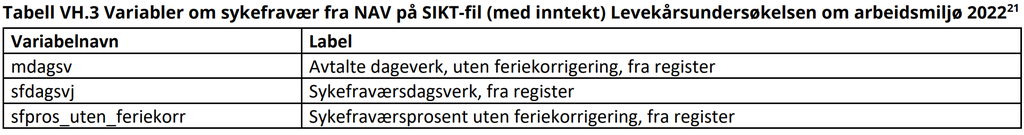

“Fra register” innebærer at dette er legemeldte sykedager (ikke egenmelding). Data fra 2022 og 2023.

Mulige “forklaringsvariabler” (avhengig av problemstilling):

- **Demografiske variabler**
  - *kullaldr* (alder)
  - *Kjonn* (kjønn)
  - *barn05 / barn617* (har små barn/skolebarn)
  - *partner* (gift/samboer)
- Egenskaper ved jobben/arbeidsplassen
  - *Sektor1/Sektor2* (privat vs. offentlig sektor)
  - *nace5s / VIRK_NACE_3sif* (næringskode)
  - *Sp6* (antall ansatte)
  - *arb_stillingspst* (stillingsprosent)
  - *timer1t/timer1m* (timer i hovedjobb)
  - *Omorg1, Omorg2* (omorganisering/nedbemanning)
- **Arbeidsmiljø**
  - *Sp59g* (tilfreds med jobben)
  - *SpMotEng_ny* (motivasjon/engasjement)
  - *Sliten1 / Sliten_a* (fysisk/psykisk utmattelse)
  - *Vold / Hets / Mobb* (utsatt for vold, trusler, mobbing på jobb)
  - *Risk0 / Risk1rev / Risk2rev* (risikovurderinger, opplæring, beskyttelse)
- **Helse**
  - *Hels1* (selv-rapportert helse)
  - *Sp64-74* (ulike helseplager)
- **Økonomiske variabler**
  - *lonn_ialt_glattet* (månedslønn)
  - *lonn* (lønnsinntekter)
  - *saminnt* (samlet inntekt)
  - *wies* (inntekt etter skatt)
  - *agg_f_08* (bruttofinanskapital)